# Week6 Tidy Tuesday - Soccer Game Info

Hannah Merges

2023-04-09

## Introduction

This week’s tidy tuesday includes a soccer dataset which looks at different teams and their wins and losses. My goal is to try and use some new packages I have learned and make fun plots with this random dataset. I also want to practice tidying data with mutate, select, and if_else to get more comfortable with these coding basics.

## Load libraries

```r
library(tidyverse)
library(here)
library(magick)
library(PNWColors)
library(patchwork)
library(GGally)
library(viridis)
library(pals)
```

## Read in Data

```r
soccer <- readr::read_csv('https://raw.githubusercontent.com/rfordatascience/tidytuesday/master/data/2023/2023-04-04/soccer21-22.csv')
```

## Manipulate the data

What am I trying to figure out? One plot could be how many fouls a team has? Who is the most aggressive team? Are they more aggressive home or away? Another question I could answer: if you are losing at half time, what is the percentage of comeback wins at the end of the game? OR does the amount of shots you take correlate with winning?

```r
## used full soccer data frame for the red cards info

## how do I want to manipulate it for the second question?
# struggling with this part
halftime <- table(soccer$HTR, exclude = NULL) ## this is in base R
prop.table(table(soccer$HTR, exclude = NULL)) ## shows %age of how many times each category occurs in dataset
```

```
##
##         A         D         H
## 0.2657895 0.3973684 0.3368421
```

```r
fulltime <- table(soccer$FTR, exclude=NULL)
fulltime
```

```
##
##   A   D   H
## 129  88 163
```

```r
##can you use tables to plot?? probably not

## making new datastets for home and away sum totals of shots on goal vs total shots

soccer_home <- soccer %>%
  group_by(HomeTeam) %>%
  summarize(sum_homegoals=sum(FTHG),
            sum_shots=sum(HS))

soccer_away <- soccer %>%
  group_by(AwayTeam) %>%
  summarize(sum_awaygoals=sum(FTAG),
            sum_shots=sum(AS))
```

## Plot the Data

This first plot will be for the sum total shots from full time scores vs how many shots are taken

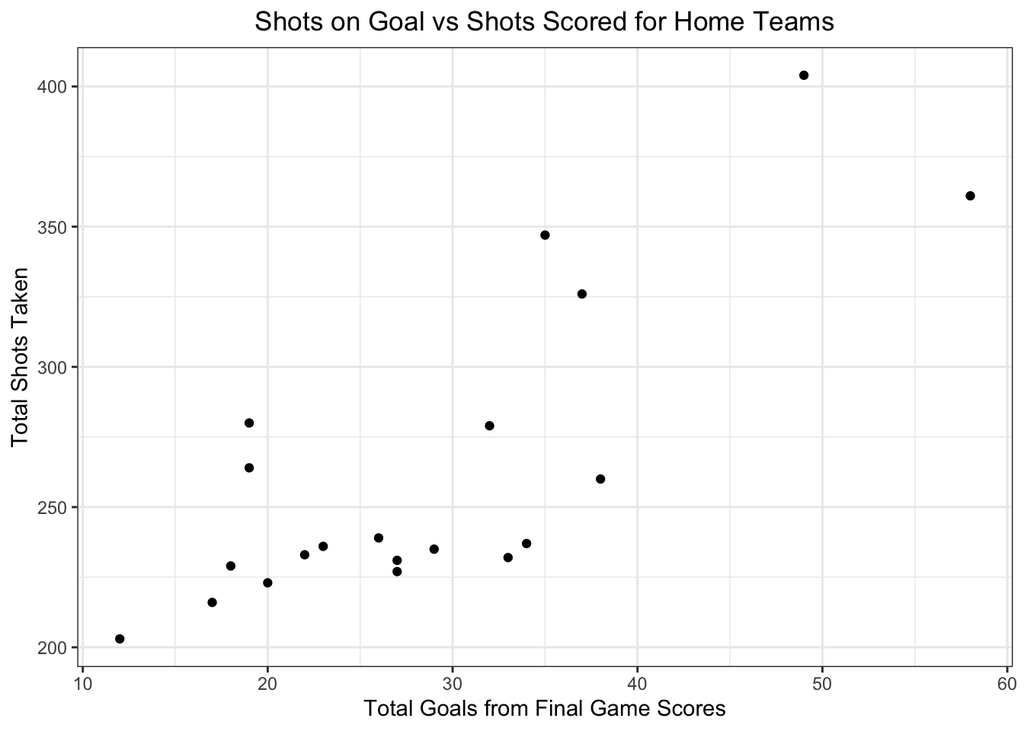

```r
ggplot(data=soccer_home,
       aes(x=sum_homegoals,
           y=sum_shots)) +
  geom_point() +
  labs(x="Total Goals from Final Game Scores",
       y="Total Shots Taken",
       title="Shots on Goal vs Shots Scored for Home Teams") +
  theme_bw() +
  theme(plot.title=element_text(hjust = 0.5))
```

```r
## only going to do this for home data this time
## even though I created both dfs
```

## Plotting the fouls

This plot will illustrate the red cards given to each team when they are home and away to investigate if a team is more aggressive when they are playing at home or away.

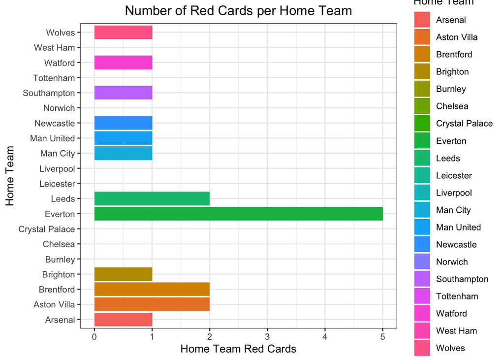

```r
p1 <- ggplot(data=soccer,
       aes(y=HomeTeam,
           x=HR,
           fill=HomeTeam)) +
  geom_col() +
  theme_bw() +
  labs(x="Home Team Red Cards",
       y="Home Team",
       title="Number of Red Cards per Home Team",
       fill="Home Team") +
  theme(plot.title=element_text(hjust = 0.5))
p1
```

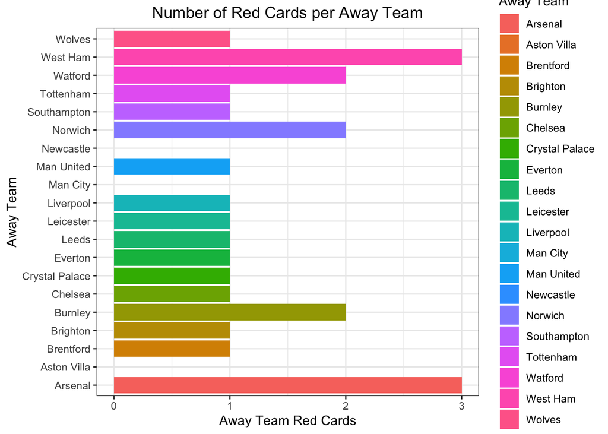

```r
p2 <- ggplot(data=soccer,
       aes(x=AR,
           y=AwayTeam,
           fill=AwayTeam)) +
  geom_col() +
  theme_bw() +
  labs(x="Away Team Red Cards",
       y="Away Team",
       title="Number of Red Cards per Away Team",
       fill="Away Team") +
  theme(plot.title=element_text(hjust = 0.5))

p2
```

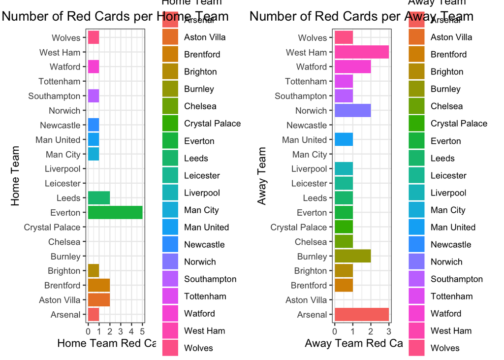

```r
p1 + p2
```

```r
  ggsave(here("Week06_Soccer", "Outputs", "redcards.jpg"),
         width=11, height=7)
```

## Summary

This tidy tuesday I explored the soccer data set which included a lot of information on soccer games, who won, shots on goals, half time and full time scores, and fouls. One thing I could not quite figure out was how to summarize the total number of wins for each time when they played as home team vs away team given that “H” and “A” were characters not numeric factors. Though overall, I am happy I got to practice more with tidying dataframes and adding new columns and explored more about patchwork.